# 渐进式教学

Hedy 教学理念

电子科技大学科学素养中心+Hedy中国

# 课程规划

## AM1

> 渐进式教学
- 编程范式差异
- 编程心理学
- 费曼学习法?

# 编程教育?

## 提问

- 编程教育最困难在哪?
- 以及尝试过什么解决方案?
- 你认为什么是最好的解决方案?

## 教育?

> 精确的陪伴…
- 谁陪伴谁?

## Scrach

> 为什么是Scrach?
- [终身幼儿园 (将创造力进行到底)](https://book.douban.com/subject/30285992/)
- [玩耍是最认真的学习 (2023)](https://book.douban.com/subject/36590055/)
- 针对儿童心理学设计的学习系统

## 创造力

- 并非来自欢笑和乐趣
  - 它来自
    - 实验,冒险和挑战边界

## 会编程?

> 和写作有什么不同?
- 什么是会编程:
  - 能将任何问题
    - 分解为自己能够解决的小问题
  - 并自信可以解决!

## 难点在…

[Hedy Introduction Talk - YouTube](https://www.youtube.com/watch?v=EdqT313rM40&t=2s)

## 同时跨越太多

> 处理不能
- Scrach:
  - 面向小学生
  - 面向图形
  - 面向交互游戏
  - 鼓励协作(外网…)

## 同时跨越太多

> 处理不能
- Python:
  - 面向交付
  - 面向文本
  - 面向多种范式
  - 鼓励社区协作

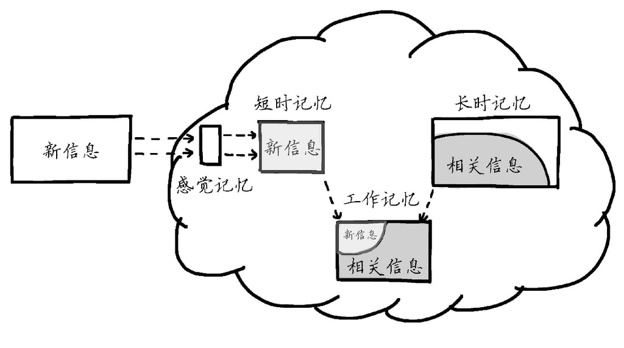

程序猿记忆体系

## FEYNMAN TECHNIQUE

- 如何证明自己学会了?
  - 能教会别人
- 具体过程:
  - 1: 获取：即获得并初步吸收自己获得的知识
  - 2: 教学：向他人讲解你所获得的知识/或者也可以想象给别人讲解的自言自语
  - 3: 回顾：由他人或者自己对自己的教学进行评价，并回顾讲的不好的地方
  - 4: 简化：简化=划重点 提炼并升华知识

# 渐进式学习

## Hedy

> 名字由来

[figure not shown]

海蒂·拉玛

## 准开发语言

> 兼容 Python
- 简化语法
- 简化界面
- 简化功能
- 逐级丰富
- 最终兼容

## 级别目标

> 自学为尚
- L1~3: 熟悉界面
- L4~8: 开始渐进
- L9~14: 引入新语法
- L15~18: 兼容 Python

## 入门级

> 自学环境
- L1/ 编程目标
- L2/ 引入变量
- L3/ 理解变量, +随机

## 体验级

> 自学任务
- L4/ ++引号, clear
- L5/ ++ if…else
- L6/ ++ 数学 = 替代 is
- L7/ ++ 重复, repeat 指令
- L8/ ++ 缩进要求

## 语汇级

> 自学交流
- L9/ 嵌套
- L10/ ++for 循环
- L11/ 用 for 替代 repeat
- L12/ ++函式
- L13/ ++ and, or, 参数
- L14/ +比较运算符

## 实用级

> 自学实用
- L15/ ++ while
- L16/ 进一步引入 Python 语法
- L17/ 完善 Python 语法
- L18/ 完成过渡进入 Python

# (￣▽￣)

## 幻灯

> NOT PPT

[slides.101.camp/hedy4cd120am1](http://slides.101.camp/hedy4cd120am1.html)

## 小结

> 关键在:
- 0: 编程难学原因
- 1: 代码难教本质
- 2: 海蒂解决方案

## 是也乎

- 240522 pub.
- 240519 re-factory
- 240501 append
- 240401 init.

[figure not shown]

ask**DAMA**@**g**oo**g**le**g**roup**s**.com

## Q&A

> ask**DAMA**@**g**oo**g**le**g**roup**s**.com

## Camp

> 比来时好
- 蟒营价值发源自**真诚**探索
- **治**疗视而不见笔记**最**有效
- 不懂**就**问是课程核心**行动**
- 编程实力积累必须**要**编程

[figure not shown]

断言v4

## 内省

> 不忘初心…
- 什么是教育?
- 什么是编程?

[figure not shown]

一个自毁倾向社区的形成

[Blogging 蟒营™ 博客](https://blog.101.camp/NC/190711-NC101-self-destruction/)

```
blog.101.camp/NC/190711-NC101-self-destruction
```

> askdama@googlegroups.com

# Hedy中国

## Felienne

[The Programmer’s Brain](https://book.douban.com/subject/35498482/)

> …What every programmer needs to know about cognition
- [程序员超强大脑 (2023)](https://book.douban.com/subject/36362026/)
  - 费莉安•赫尔曼斯（Felienne Hermans），荷兰莱顿大学副教授，致力于研究人类如何利用认知科学快速、高效地学习程序设计语言。
    - 她是TC39（JavaScript标准委员会） 成员，还自创了Hedy程序设计语言。

## Why?

> [Hedy Introduction Talk - YouTube](https://www.youtube.com/watch?v=EdqT313rM40)
- 解决从 Scrach 到 Python 之类开发语言学习过程中的痛点
  - 难以学会…

## 遇见

> 2023
- 大妈, 自媒体
- Jason 主动探访
- 选择方向
  - Hedy
  - 加速中国编程教育

## 机会

> 2024
- “成都+少儿编程”
- 成都青少年宫文章…
  - 电子科大
  - 彭老师
    - 贵州, 科技课程培训